# `Term Deposit Sale - Bank Marketing`

## `Domain:`

Banking

## `Data Description:`

The data is related with direct marketing campaigns of a Portuguese banking institution. The marketing campaigns were based on phone calls. Often, more than one contact to the same client was required, in order to access if the product (bank term deposit) would be ('yes') or not ('no') subscribed.

[Moro et al., 2014] S. Moro, P. Cortez and P. Rita. A Data-Driven Approach to Predict the Success of Bank Telemarketing. Decision Support Systems, Elsevier, 62:22-31, June 2014

https://archive.ics.uci.edu/ml/datasets/Bank+Marketing

## `Attributes Information:`

### Bank client data:

- **age**: numeric
- **job**: : categorical, type of job ('admin.', 'blue-collar', 'entrepreneur', 'housemaid', 'management', 'retired', 'self-employed', 'services', 'student', 'technician', 'unemployed', 'unknown')
- **marital**: : categorical, marital status ('divorced', 'married', 'single', 'unknown'). 'divorced' means divorced or widowed.
- **education**: categorical, education level ('tertiary', 'secondary', 'unknown', 'primary')
- **default**: categorical, has credit in default? ('no','yes','unknown')
- **housing**: categorical, has housing loan? ('no','yes','unknown')
- **loan**: categorical, has personal loan? ('no','yes','unknown')
- **balance**: balance in account

### Related with the last contact of the current campaign:

- **contact**: categorical, contact communication type ('cellular', 'telephone')
- **month**: categorical, last contact month of year ('jan', 'feb', 'mar', ..., 'nov', 'dec')
- **day**: categorical, last contact day of the month
- **duration**: numeric, last contact duration, in seconds.

### Other attributes:

- **campaign**: numeric, number of contacts performed during this campaign and for this client
- **pdays**: numeric, number of days that passed by after the client was last contacted from a previous campaign (-1 tells us the person has not been contacted or contact period is beyond 900 days)
- **previous**: numeric, number of times the client has been contacted before to subscribe term deposit
- **poutcome**: categorical, outcome of the previous marketing campaign ('failure', 'nonexistent', 'success')

### Output variable:

- **Target**: binary, desired target, has the client subscribed a term deposit? ('yes','no')

## `Goal:`

Using the data collected from existing customers, build a model that will help the marketing team identify potential customers who are relatively more likely to subscribe term deposit and thus increase their hit ratio.

## `Steps and tasks`

1. Libraries & Dataset Import
2. EDA
1. Univariate Analysis
2. Bivariate Analysis
3. Getting data model ready
4. Split Data
3. Classifiers
1. Logistic Regression
2. Decison Tree (CART)
3. Ensemble - Bagging
4. Ensemble - AdaBoostin
5. Ensemble - GradientBoost
6. Ensemble - RandomForest Classifier
7. Ensemble - XGBClassifier
4. Comparison
5. Conclusions

## 1. Libraries & Dataset Import

```python
# Basic imports
import pandas as pd
import numpy as np

# Plots
import matplotlib.pyplot as plt
%matplotlib inline
import seaborn as sns

import warnings
warnings.filterwarnings('ignore')

from IPython.core.display import display
```

```python
df = pd.read_csv('bank-full.csv')
df.head()
```

|  | age | job | marital | education | default | balance | housing | loan | contact | day | month | duration | campaign | pdays | previous | poutcome | Target |
| --- | --- | --- | --- | --- | --- | --- | --- | --- | --- | --- | --- | --- | --- | --- | --- | --- | --- |
| 0 | 58 | management | married | tertiary | no | 2143 | yes | no | unknown | 5 | may | 261 | 1 | -1 | 0 | unknown | no |
| 1 | 44 | technician | single | secondary | no | 29 | yes | no | unknown | 5 | may | 151 | 1 | -1 | 0 | unknown | no |
| 2 | 33 | entrepreneur | married | secondary | no | 2 | yes | yes | unknown | 5 | may | 76 | 1 | -1 | 0 | unknown | no |
| 3 | 47 | blue-collar | married | unknown | no | 1506 | yes | no | unknown | 5 | may | 92 | 1 | -1 | 0 | unknown | no |
| 4 | 33 | unknown | single | unknown | no | 1 | no | no | unknown | 5 | may | 198 | 1 | -1 | 0 | unknown | no |

```python
df.shape
```

```
(45211, 17)
```

## 2. EDA

### Univariate Analysis

```python
df.info()
```

```
<class 'pandas.core.frame.DataFrame'>
RangeIndex: 45211 entries, 0 to 45210
Data columns (total 17 columns):
 #   Column     Non-Null Count  Dtype
---  ------     --------------  -----
 0   age        45211 non-null  int64
 1   job        45211 non-null  object
 2   marital    45211 non-null  object
 3   education  45211 non-null  object
 4   default    45211 non-null  object
 5   balance    45211 non-null  int64
 6   housing    45211 non-null  object
 7   loan       45211 non-null  object
 8   contact    45211 non-null  object
 9   day        45211 non-null  int64
 10  month      45211 non-null  object
 11  duration   45211 non-null  int64
 12  campaign   45211 non-null  int64
 13  pdays      45211 non-null  int64
 14  previous   45211 non-null  int64
 15  poutcome   45211 non-null  object
 16  Target     45211 non-null  object
dtypes: int64(7), object(10)
memory usage: 5.9+ MB
```

**Insights:**

- There are 45211 entries in the dataset.
- There are no NULL values.

```python
df.describe().T
```

|  | count | mean | std | min | 25% | 50% | 75% | max |
| --- | --- | --- | --- | --- | --- | --- | --- | --- |
| age | 45211.0 | 40.936210 | 10.618762 | 18.0 | 33.0 | 39.0 | 48.0 | 95.0 |
| balance | 45211.0 | 1362.272058 | 3044.765829 | -8019.0 | 72.0 | 448.0 | 1428.0 | 102127.0 |
| day | 45211.0 | 15.806419 | 8.322476 | 1.0 | 8.0 | 16.0 | 21.0 | 31.0 |
| duration | 45211.0 | 258.163080 | 257.527812 | 0.0 | 103.0 | 180.0 | 319.0 | 4918.0 |
| campaign | 45211.0 | 2.763841 | 3.098021 | 1.0 | 1.0 | 2.0 | 3.0 | 63.0 |
| pdays | 45211.0 | 40.197828 | 100.128746 | -1.0 | -1.0 | -1.0 | -1.0 | 871.0 |
| previous | 45211.0 | 0.580323 | 2.303441 | 0.0 | 0.0 | 0.0 | 0.0 | 275.0 |

**Insights:**

- All clients are in the **age** range **[18;95]** years, and **50%** within **[33;48]**.
- **pdays** - 75% of people have value -1 which tells us that client had not been contacted before or more than 900 days had passed.
- Same picture with **previous**, 75% of people have not been contacted before.
- We can see that although usually (75%) bank contacts people 1-3 times (**campaign**), for some people it takes up to **63** times.
- **duration** - last contact in seconds, we can see that although the min is 0, more than 75% of people were on the call for more than 103 seconds, and hence 75% of people were contacted during this campaign. Variable exibits strong **positive skewness**.
- **balance** - we can see that some people have negative balance, the amount is less than 25%, on the other side in top 25% people can have big balances. **50%** of the clients has balances **[72;1428]**. The variable is **positively skewed**.

```python
df.nunique()
```

```
age            77
job            12
marital         3
education       4
default         2
balance      7168
housing         2
loan            2
contact         3
day            31
month          12
duration     1573
campaign       48
pdays         559
previous       41
poutcome        4
Target          2
dtype: int64
```

**Insights:**

- Here we can confirm categorical variables: **job, marital, education, poutcome, contact**.
- Categorical binary: **default, housing, loan**. Output variable **Target** is also binary.
- Numerical discrete: **month, day**. **Note:** Although **month** is represented by names (qualitative ordinal) we can convert it to numbers from 1 to 12, and we will do this later. **age**, **campaign**, **pdays** and **previous** could be considered discrete for our purposes, as we can difenetely count them finitely.
- Numerical continuous: **balance** and **duration**.

```python
df.isnull().sum()
```

```
age          0
job          0
marital      0
education    0
default      0
balance      0
housing      0
loan         0
contact      0
day          0
month        0
duration     0
campaign     0
pdays        0
previous     0
poutcome     0
Target       0
dtype: int64
```

**Insights:**

- Confirmed again that we have no NULL values

### Categorical Binary Variables

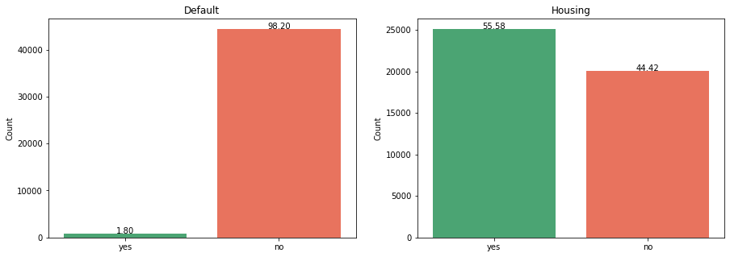

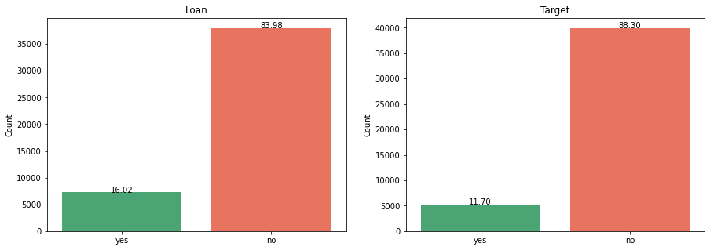

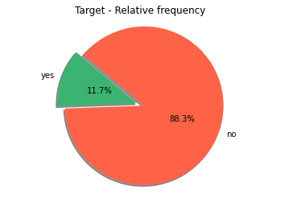

```
default
no     44396
yes      815
Name: default, dtype: int64

housing
yes    25130
no     20081
Name: housing, dtype: int64

loan
no     37967
yes     7244
Name: loan, dtype: int64

Target
no     39922
yes     5289
Name: Target, dtype: int64
```

```python
cat_bin_vars = ['default', 'housing', 'loan', 'Target']

def plot_counts_percentages(data, col):
    total_clients = data.shape[0]
    chart = sns.countplot(data[col], order = ['yes', 'no'], palette=['mediumseagreen', 'tomato']);
    chart.set(title=col.title(), xlabel='', ylabel='Count')
    for p in chart.patches:
        height = p.get_height()
        chart.text(p.get_x() + p.get_width()/2., height + 3, '{:1.2f}'.format((height/total_clients)*100), ha='center')

def display_pair(data, col1, col2):
    plt.figure(figsize=(15,5))

    plt.subplot(1, 2, 1)
    plot_counts_percentages(data, col1)

    plt.subplot(1, 2, 2)
    plot_counts_percentages(data, col2)

    plt.show()

pairs = np.array(cat_bin_vars).reshape((2,2))

for cat_cols in pairs:
    display_pair(df, cat_cols[0], cat_cols[1])

plt.pie(
        [df[df['Target'] == 'yes']['Target'].count(), df[df['Target'] == 'no']['Target'].count()],
        explode = (0.1, 0),
        labels = sorted(df['Target'].unique(), reverse=True),
        colors = ['mediumseagreen', 'tomato'],
        autopct='%1.1f%%',
        shadow=True,
        startangle=140,
        pctdistance=0.5,
        labeldistance=1.1)
plt.axis('equal')
plt.title('Target - Relative frequency')
plt.show()

for cat_col in cat_bin_vars:
    print(cat_col)
    print(df[cat_col].value_counts())
    print()
```

**Insights:**

- There are only **1.8%** of clients who **defalted**.
- **55.58%** have **housing loan**.
- Only **16%** of clients have **personal loan**.

**Data disbalance!** Dataset has big **disbalance** of **Target** variable towards people who did not subscribe a term deposit.

### Other Categorival Variables

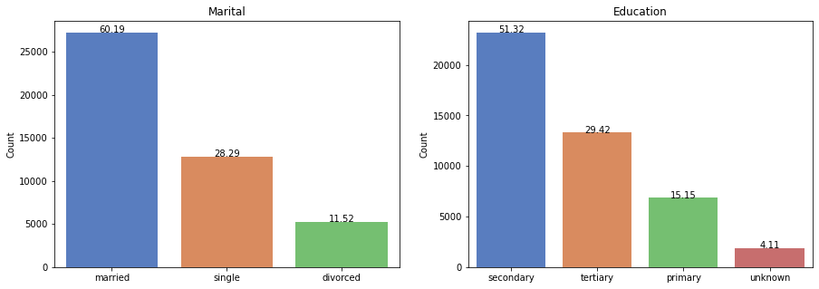

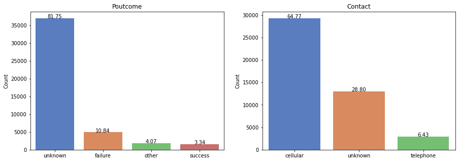

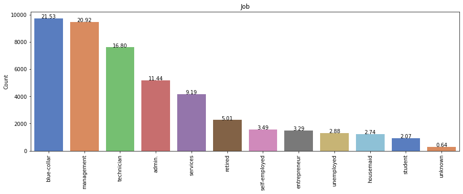

```
marital
married     27214
single      12790
divorced     5207
Name: marital, dtype: int64

education
secondary    23202
tertiary     13301
primary       6851
unknown       1857
Name: education, dtype: int64

poutcome
unknown    36959
failure     4901
other       1840
success     1511
Name: poutcome, dtype: int64

contact
cellular     29285
unknown      13020
telephone     2906
Name: contact, dtype: int64

job
blue-collar      9732
management       9458
technician       7597
admin.           5171
services         4154
retired          2264
self-employed    1579
entrepreneur     1487
unemployed       1303
housemaid        1240
student           938
unknown           288
Name: job, dtype: int64
```

```python
cat_vars = ['marital', 'education', 'poutcome', 'contact']

def plot_counts_percentages(data, col, vr=0):
    total_clients = data.shape[0]
    chart = sns.countplot(data[col], order = data[col].value_counts().index, palette='muted');
    chart.set(title=col.title(), xlabel='', ylabel='Count')
    chart.set_xticklabels(chart.get_xticklabels(),  rotation=vr)
    for p in chart.patches:
        height = p.get_height()
        chart.text(p.get_x() + p.get_width()/2., height + 3, '{:1.2f}'.format((height/total_clients)*100), ha='center')

def display_pair(data, col1, col2):
    plt.figure(figsize=(15,5))

    plt.subplot(1, 2, 1)
    plot_counts_percentages(data, col1)

    plt.subplot(1, 2, 2)
    plot_counts_percentages(data, col2)

    plt.show()

pairs = np.array(cat_vars).reshape((2,2))

for cat_cols in pairs:
    display_pair(df, cat_cols[0], cat_cols[1])

plt.figure(figsize=(15,5))
plot_counts_percentages(df, 'job', vr=90)
plt.show()


for cat_col in cat_vars + ['job']:
    print(cat_col)
    print(df[cat_col].value_counts())
    print()
```

**Insights:**

- About **60%** of the clients are married.
- More than **50%** of the clients have **secondary** education, and about **29%** - **teritary**. We have **4%** of people with **unknown** education. We can say that this variable can be ordered and so we can convert it to numbers. We don't know what those **4%** of **unknown** educations are, we won't make any assumptions and we won't drop or replace **unknown**. Let's keep them and assign **-1** to keep the orderdering right.
- In **81%** of all cases the outcome of the previous marketing campaign is **unknown**, this probably signifies newly arrived clients, however this is too much of an unknown, should consider dropping the column.
- For **28%** of the clients the **communication type** is **unknown**, but it is clear that majority of the clients (**64%**) were contacted by **cell phone**. We cannot specially treat the **unknown** because of the amount, so we either drop the column or keep it.
- Up to **59%** of the clients work as **blue-collor, management** or **technician**. **0.64** has **unknown** occupation which won't help us in prediction and we should drop it.
- **Day** & **Month**

```python
df[['day']].skew()
```

```
day    0.093079
dtype: float64
```

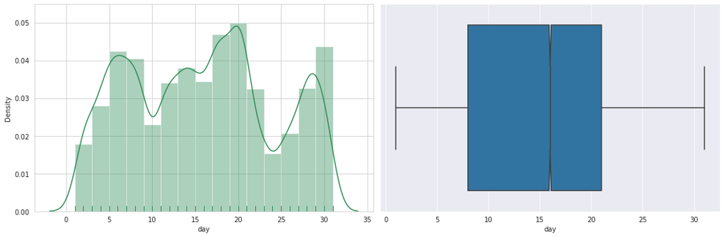

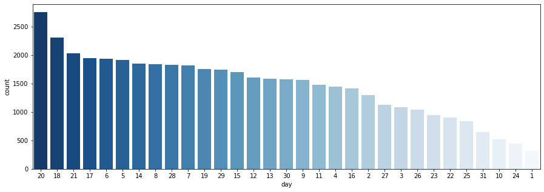

```python
for col in ['day']:
    f = plt.figure(figsize=(15,5))
    gs = f.add_gridspec(1, 2)

    with sns.axes_style("whitegrid"):
        ax = f.add_subplot(gs[0, 0])
        sns.distplot(df[col], color='seagreen', kde=True, rug=True, bins=15)

    with sns.axes_style("darkgrid"):
        ax = f.add_subplot(gs[0, 1])
        sns.boxplot(x=df[col], notch = True)

    f.tight_layout()
    plt.show()

plt.figure(figsize=(15,5))
sns.countplot(df['day'], order = df['day'].value_counts().index, palette='Blues_r')
plt.show()
```

**Insights:**

- **Day** has low skew. Also there are kind of 3 "peaks" which we could use while converting to categorical variable.

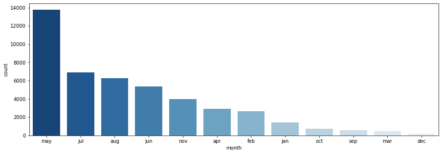

```
Skew: 0.2428419469883421
```

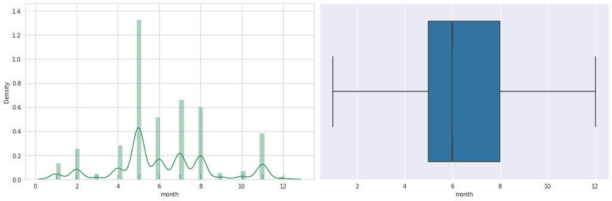

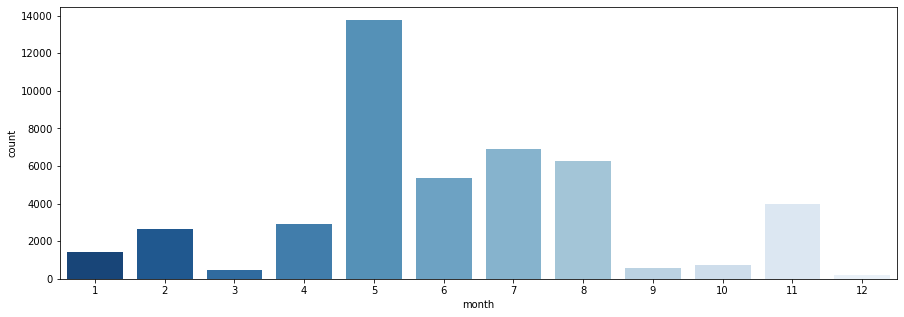

```python
plt.figure(figsize=(15,5))
sns.countplot(df['month'], order = df['month'].value_counts().index, palette='Blues_r')
plt.show()

month_num_s = df['month'].replace(
    ['jan', 'feb', 'mar', 'apr', 'may', 'jun', 'jul', 'aug', 'sep', 'oct', 'nov', 'dec'],
    [1, 2, 3, 4, 5, 6, 7, 8, 9, 10, 11, 12])

print('Skew:', month_num_s.skew())

f = plt.figure(figsize=(15,5))
gs = f.add_gridspec(1, 2)

with sns.axes_style("whitegrid"):
    ax = f.add_subplot(gs[0, 0])
    sns.distplot(month_num_s, color='seagreen', kde=True, rug=True, bins=48)

with sns.axes_style("darkgrid"):
    ax = f.add_subplot(gs[0, 1])
    sns.boxplot(x=month_num_s, notch = True)

f.tight_layout()
plt.show()

plt.figure(figsize=(15,5))
sns.countplot(month_num_s, palette='Blues_r')
plt.show()
```

**Insights:**

### Define Utility Functions

```python
def display_num_stats(data, col, hist_color='seagreen', box_color='steelblue'):
    f = plt.figure(figsize=(15,5))
    gs = f.add_gridspec(1, 2)

    with sns.axes_style("whitegrid"):
        ax = f.add_subplot(gs[0, 0])
        sns.distplot(data[col], color=hist_color, kde=True, rug=True)

    with sns.axes_style("darkgrid"):
        ax = f.add_subplot(gs[0, 1])
        sns.boxplot(x=data[col], notch = True, color=box_color)

    f.tight_layout()
    plt.show()

    # Computing IQR
    Q1 = data[col].quantile(0.25)
    Q3 = data[col].quantile(0.75)
    IQR = Q3 - Q1
    LWhisker = Q1 - 1.5 * IQR
    UWhisker = Q3 + 1.5 * IQR
    UpperOutliers = data[data[col] > UWhisker][col].count();
    LowerOutliers = data[data[col] < LWhisker][col].count();

    print(col.title())
    print('Skew:', data[col].skew())
    print('Lower whisker', LWhisker)
    print('Upper whisker', UWhisker)
    print('Outliers above upper whisker: ', UpperOutliers, '({:.1f}%)'.format( (UpperOutliers/data.shape[0])*100) )
    print('Outliers under lower whisker: ', LowerOutliers, '({:.1f}%)'.format( (LowerOutliers/data.shape[0])*100) )
```

- **Age**

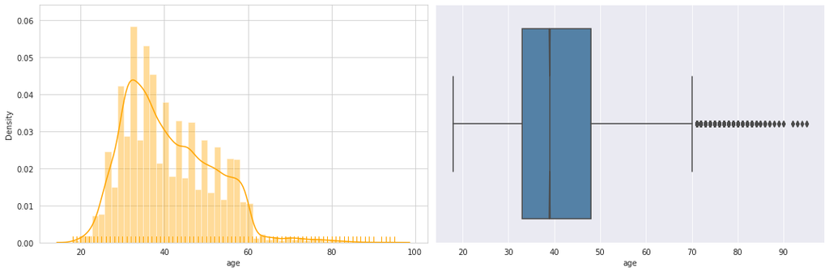

```
Age
Skew: 0.6848179257252598
Lower whisker 10.5
Upper whisker 70.5
Outliers above upper whisker:  487 (1.1%)
Outliers under lower whisker:  0 (0.0%)
```

```python
display_num_stats(df, 'age', hist_color='orange')
```

**Insights:**

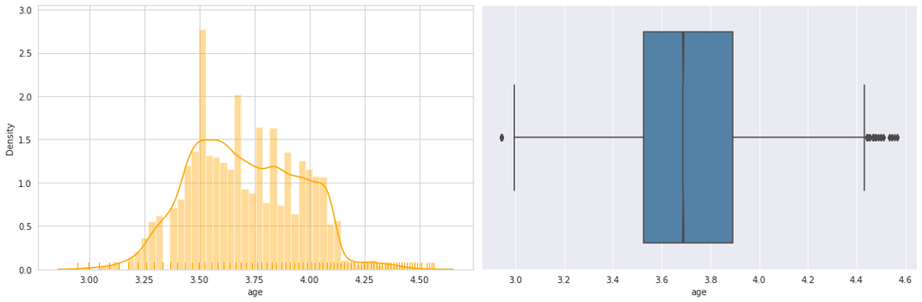

```
Age
Skew: 0.112757280039432
Lower whisker 2.978170864374464
Upper whisker 4.440009958352324
Outliers above upper whisker:  41 (0.1%)
Outliers under lower whisker:  12 (0.0%)
```

```python
from sklearn.preprocessing import FunctionTransformer
log_transformer = FunctionTransformer(np.log1p)

test_age_log = df.copy()
test_age_log['age'] = log_transformer.fit_transform(test_age_log[['age']])

display_num_stats(test_age_log, 'age', hist_color='orange')
```

**Insights:**

- By transforming **age** with **log** we significantly reduced skewness.
- **Balance, Duration, Pdays, Previous and Campaign**

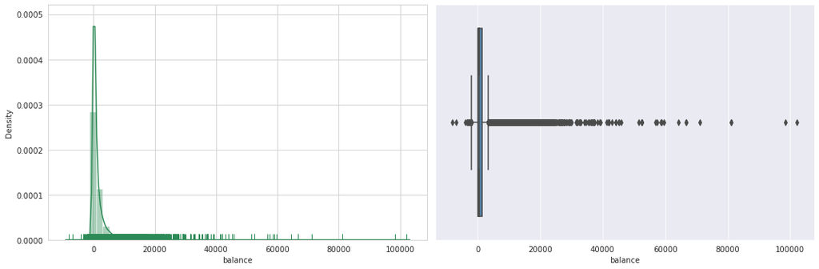

```
Balance
Skew: 8.360308326166326
Lower whisker -1962.0
Upper whisker 3462.0
Outliers above upper whisker:  4712 (10.4%)
Outliers under lower whisker:  17 (0.0%)
```

```python
display_num_stats(df, 'balance')
```

**Insights:**

- **Balance** has strong **positive skew**. We have **10%** of data points as outliers. Binning can help to see the distribution more clearly. But regardless of that, all amounts are ok, we can have negative balances, as well as very big positive balances.

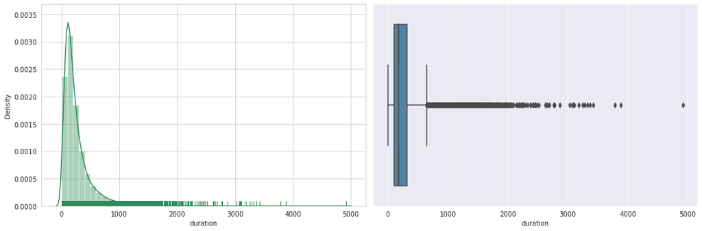

```
Duration
Skew: 3.144318099423456
Lower whisker -221.0
Upper whisker 643.0
Outliers above upper whisker:  3235 (7.2%)
Outliers under lower whisker:  0 (0.0%)
```

```python
display_num_stats(df, 'duration')
```

**Insights:**

- **Duration** has very strong **positive skew**. But regardless of skewness, **duration** highly affects the output **Target** e.g., if **duration** = 0 then **Traget** = 'no'. Yet, the duration is not known before a call is performed. Also, after the end of the call **Traget** is obviously known. Because our task is to predict future outcome we need to discard this variable to have a realistic predictive model.

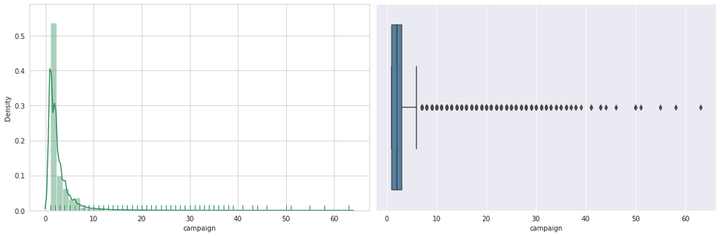

```
Campaign
Skew: 4.898650166179674
Lower whisker -2.0
Upper whisker 6.0
Outliers above upper whisker:  3064 (6.8%)
Outliers under lower whisker:  0 (0.0%)
```

```python
 display_num_stats(df, 'campaign')
```

**Insights:**

- **campaign** - number of contacts performed during this campaign and for this client. Strong **positive skew**. Some big counts are questionable, why would the bank call 60 times for instance? One possible explanation is that this variable represents a number of attempts to contact a client and not the actual number of conversations. From this perspective all the numbers look good.

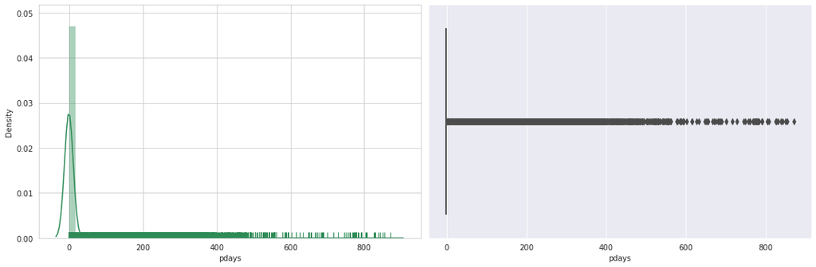

```
Pdays
Skew: 2.6157154736563477
Lower whisker -1.0
Upper whisker -1.0
Outliers above upper whisker:  8257 (18.3%)
Outliers under lower whisker:  0 (0.0%)
```

```python
 display_num_stats(df, 'pdays')
```

**Insights:**

- **pdays** - number of days that passed by after the client was last contacted from a previous campaign. We can see that **81.7%** of clients were not contacted or contacted more than 900 days ago, represented by **-1**.

Let's see the distribution for the clients who have been contacted.

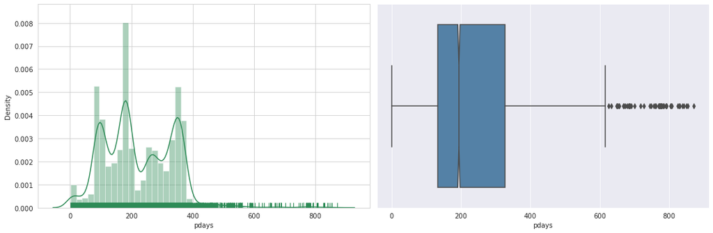

```
Pdays
Skew: 0.6931397093928039
Lower whisker -158.0
Upper whisker 618.0
Outliers above upper whisker:  49 (0.6%)
Outliers under lower whisker:  0 (0.0%)
```

```
count    8257.000000
mean      224.577692
std       115.344035
min         1.000000
25%       133.000000
50%       194.000000
75%       327.000000
max       871.000000
Name: pdays, dtype: float64
```

```python
only_contacted_clients = df[df['pdays'] != -1]
display_num_stats(only_contacted_clients, 'pdays')
only_contacted_clients['pdays'].describe()
```

**Insights:**

- **mean** is close to **median** for **pdays** and roughly is **200** days. **50%** of the clients were contacted **[133;327]** days ago from a previous campaign.
- There are **49** outliers which accounts for **0.6%**. Numbers within norm for this bank as it can go up to 900 before reset happens.

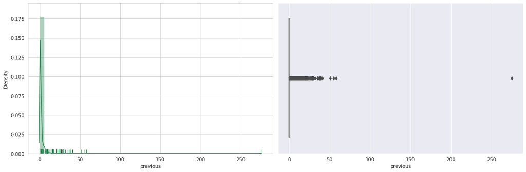

```
Previous
Skew: 41.84645447266292
Lower whisker 0.0
Upper whisker 0.0
Outliers above upper whisker:  8257 (18.3%)
Outliers under lower whisker:  0 (0.0%)
```

|  | age | job | marital | education | default | balance | housing | loan | contact | day | month | duration | campaign | pdays | previous | poutcome | Target |
| --- | --- | --- | --- | --- | --- | --- | --- | --- | --- | --- | --- | --- | --- | --- | --- | --- | --- |
| 29182 | 40 | management | married | tertiary | no | 543 | yes | no | cellular | 2 | feb | 349 | 2 | 262 | 275 | other | no |

```python
display_num_stats(df, 'previous')

# extreme outliers
display(df[df['previous'] > 250])
```

**Insights:**

- **previous** - number of times the client has been contacted before. Extreame **positive skewness**. Again, we already know that **81.7%** of clients were not contacted before.
- Also we can see one **extreame** outlier, who was contacted **275** times! We should definetly drop this one as it is not a part of any valuable for our prediction pattern.

Let's see the distribution for the clients who have been contacted.

```
Based on pdays:
```

```
count    8256.000000
mean        3.144622
std         3.442657
min         1.000000
25%         1.000000
50%         2.000000
75%         4.000000
max        58.000000
Name: previous, dtype: float64
```

```
Based on previous:
```

```
count    8256.000000
mean        3.144622
std         3.442657
min         1.000000
25%         1.000000
50%         2.000000
75%         4.000000
max        58.000000
Name: previous, dtype: float64
```

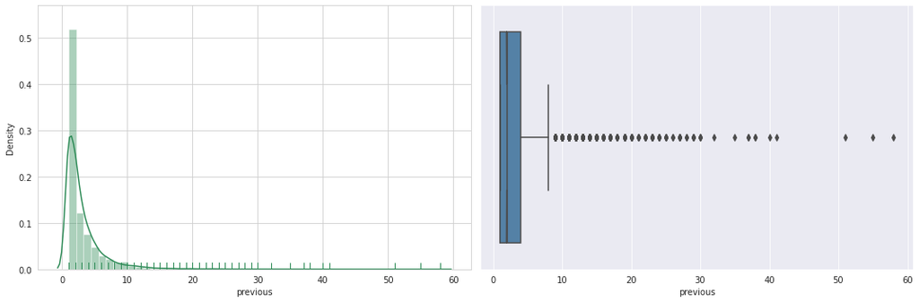

```
Previous
Skew: 4.66472836741307
Lower whisker -3.5
Upper whisker 8.5
Outliers above upper whisker:  452 (5.5%)
Outliers under lower whisker:  0 (0.0%)
```

```python
# Drop extreme outlier
clean_df = df[df['previous'] != 275]

only_contacted_clients_by_pdays = clean_df[clean_df['pdays'] != -1]
only_contacted_clients_by_previous = clean_df[clean_df['previous'] > 0 ]

print('Based on pdays:')
display(only_contacted_clients_by_pdays['previous'].describe().T)

print('Based on previous:')
display(only_contacted_clients_by_previous['previous'].describe().T)

display_num_stats(only_contacted_clients_by_pdays, 'previous')
```

**Insights:**

- We confirmed that **pday** & **previous** are both indicating the same clients who were or weren't contacted. And for these clients we know how many days had passed and number of calls made.
- We can see that **50%** of the clients were contacted **[1;4]** times.
- Similarly to the **campaign** variable, **previous** has some big numbers which probably is really just a number of call attempts. From this perspective all the numbers are good.

## Bivariate Analysis

### Target vs Categorical Variables

- **Job**

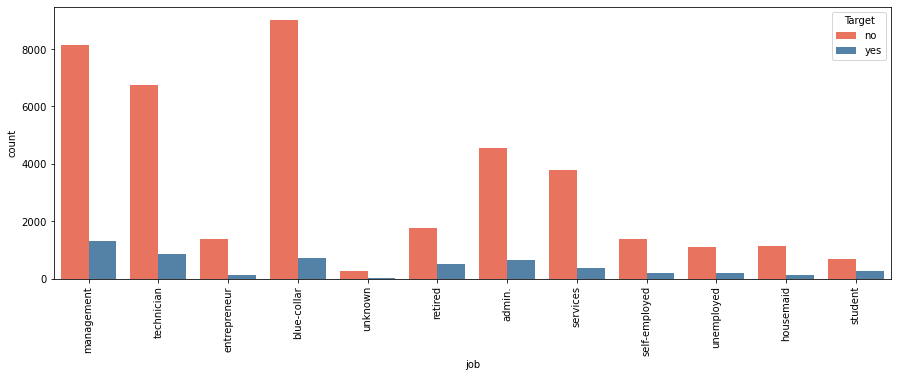

| Target job | no | yes | All |
| --- | --- | --- | --- |
| management | 0.204323 | 0.245982 | 0.209197 |
| technician | 0.169255 | 0.158820 | 0.168034 |
| blue-collar | 0.226041 | 0.133863 | 0.215257 |
| admin. | 0.113722 | 0.119304 | 0.114375 |
| retired | 0.043785 | 0.097561 | 0.050076 |
| services | 0.094810 | 0.069767 | 0.091880 |
| student | 0.016758 | 0.050860 | 0.020747 |
| unemployed | 0.027579 | 0.038192 | 0.028820 |
| self-employed | 0.034868 | 0.035356 | 0.034925 |
| entrepreneur | 0.034167 | 0.023256 | 0.032890 |
| housemaid | 0.028330 | 0.020609 | 0.027427 |
| unknown | 0.006362 | 0.006428 | 0.006370 |

```python
plt.figure(figsize=(15,5))
chart = sns.countplot(df['job'], hue=df['Target'], palette=['tomato', 'steelblue'])
chart.set_xticklabels(chart.get_xticklabels(), rotation=90)
plt.show()
pd.crosstab(df['job'], df['Target'], margins=True, normalize='columns').sort_values(by='yes', ascending=False)
```

**Insights:**

- We can see that amongst all occupations **top 5** for positive subscribtion are **management**, **technician**, **blue-collar**, **admin.** and **retired**. All these groups together constitute the majority of clients.

```python
pd.crosstab(df['job'], df['Target'], normalize='index').sort_values(by='yes', ascending=False)
```

| Target job | no | yes |
| --- | --- | --- |
| student | 0.713220 | 0.286780 |
| retired | 0.772085 | 0.227915 |
| unemployed | 0.844973 | 0.155027 |
| management | 0.862444 | 0.137556 |
| admin. | 0.877973 | 0.122027 |
| self-employed | 0.881571 | 0.118429 |
| unknown | 0.881944 | 0.118056 |
| technician | 0.889430 | 0.110570 |
| services | 0.911170 | 0.088830 |
| housemaid | 0.912097 | 0.087903 |
| entrepreneur | 0.917283 | 0.082717 |
| blue-collar | 0.927250 | 0.072750 |

**Insights:**

- However within each particular occupation **top 5** is different: **student**, **retired**, **unemployed**, **management** and **admin.**.
- **Marital**

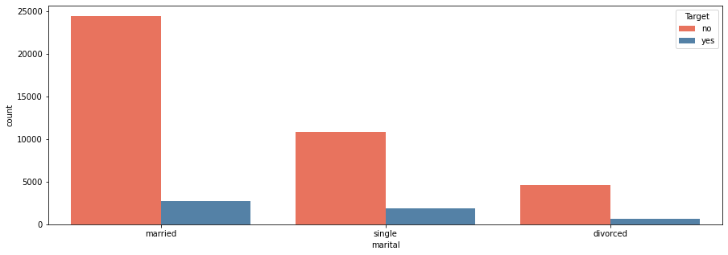

| Target marital | no | yes |
| --- | --- | --- |
| divorced | 0.880545 | 0.119455 |
| married | 0.898765 | 0.101235 |
| single | 0.850508 | 0.149492 |
| All | 0.883015 | 0.116985 |

```python
plt.figure(figsize=(15,5))
chart = sns.countplot(df['marital'], hue=df['Target'], palette=['tomato', 'steelblue'])
plt.show()

pd.crosstab(df['marital'], df['Target'], margins=True, normalize='index')
```

**Insights:**

- In general subscribtion rate is low and about **11%** overall. Within the groups, **single** people have a slightly higher rate ~**15%**.

```python
pd.crosstab(df['marital'], df['Target'], margins=True, normalize='columns').sort_values(by='yes', ascending=False)
```

| Target marital | no | yes | All |
| --- | --- | --- | --- |
| married | 0.612670 | 0.520892 | 0.601933 |
| single | 0.272481 | 0.361505 | 0.282896 |
| divorced | 0.114849 | 0.117603 | 0.115171 |

**Insights:**

- However out of all 'yes'es, **52%** came from **married** people.
- **Education**

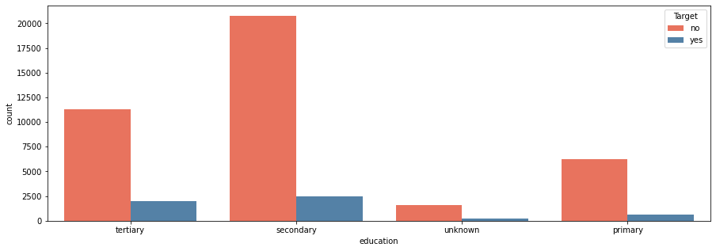

| Target education | no | yes |
| --- | --- | --- |
| primary | 0.913735 | 0.086265 |
| secondary | 0.894406 | 0.105594 |
| tertiary | 0.849936 | 0.150064 |
| unknown | 0.864297 | 0.135703 |
| All | 0.883015 | 0.116985 |

```python
plt.figure(figsize=(15,5))
chart = sns.countplot(df['education'], hue=df['Target'], palette=['tomato', 'steelblue'])
plt.show()

pd.crosstab(df['education'], df['Target'], margins=True, normalize='index')
```

**Insights:**

- Overall rate is low and ~**11%**. Looking from the perspective of single category, people with **tertiary** education tend to subscribe a little bit more often.

```python
pd.crosstab(df['education'], df['Target'], margins=True, normalize='columns').sort_values(by='yes', ascending=False)
```

| Target education | no | yes | All |
| --- | --- | --- | --- |
| secondary | 0.519814 | 0.463226 | 0.513194 |
| tertiary | 0.283177 | 0.377387 | 0.294198 |
| primary | 0.156806 | 0.111741 | 0.151534 |
| unknown | 0.040203 | 0.047646 | 0.041074 |

**Insights:**

- Looking from the perspective of all **yes'es**, people with **secondary** education constitute about **46%**.
- **Default**

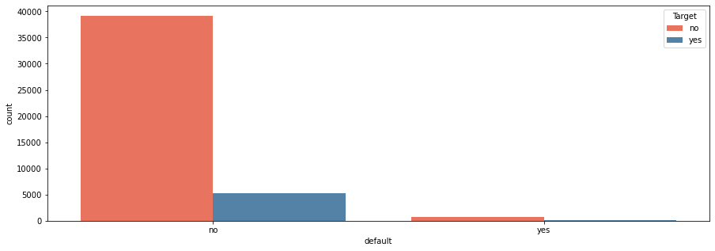

| Target default | no | yes |
| --- | --- | --- |
| no | 0.882039 | 0.117961 |
| yes | 0.936196 | 0.063804 |
| All | 0.883015 | 0.116985 |

```python
plt.figure(figsize=(15,5))
chart = sns.countplot(df['default'], hue=df['Target'], palette=['tomato', 'steelblue'])
plt.show()

pd.crosstab(df['default'], df['Target'], margins=True, normalize='index')
```

**Insights:**

- Acceptance rate is low, but people with no **default** can subscribe a little bit more often.

```python
pd.crosstab(df['default'], df['Target'], margins=True, normalize='columns').sort_values(by='yes', ascending=False)
```

| Target default | no | yes | All |
| --- | --- | --- | --- |
| no | 0.980888 | 0.990168 | 0.981973 |
| yes | 0.019112 | 0.009832 | 0.018027 |

**Insights:**

- Again about **99%** of all subscribtions is comming from people with no **default**.
- **Housing**

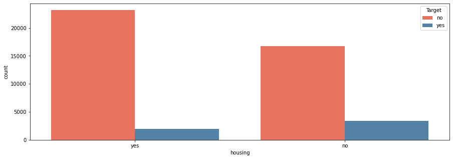

| Target housing | no | yes |
| --- | --- | --- |
| no | 0.832976 | 0.167024 |
| yes | 0.923000 | 0.077000 |
| All | 0.883015 | 0.116985 |

```python
plt.figure(figsize=(15,5))
chart = sns.countplot(df['housing'], hue=df['Target'], palette=['tomato', 'steelblue'])
plt.show()

pd.crosstab(df['housing'], df['Target'], margins=True, normalize='index')
```

**Insights:**

- Acceptance rate is low, but people with no **housing** can subscribe a little bit more often.

```python
pd.crosstab(df['housing'], df['Target'], margins=True, normalize='columns').sort_values(by='yes', ascending=False)
```

| Target housing | no | yes | All |
| --- | --- | --- | --- |
| no | 0.418992 | 0.634146 | 0.444162 |
| yes | 0.581008 | 0.365854 | 0.555838 |

**Insights:**

- Again about **63%** of all subscribtions is comming from people with no **housing**.
- **Loan**

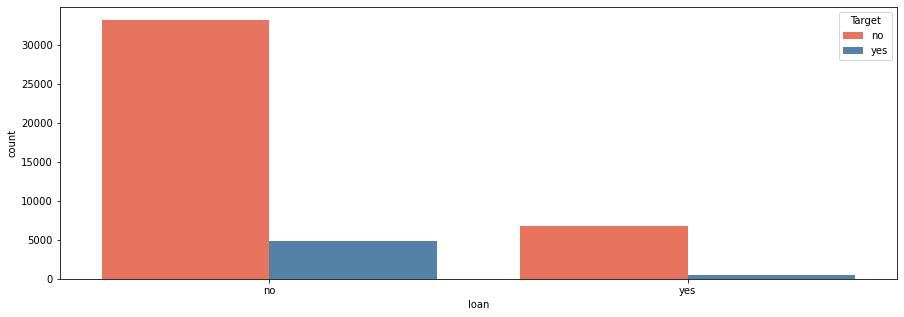

| Target loan | no | yes |
| --- | --- | --- |
| no | 0.873443 | 0.126557 |
| yes | 0.933186 | 0.066814 |
| All | 0.883015 | 0.116985 |

```python
plt.figure(figsize=(15,5))
chart = sns.countplot(df['loan'], hue=df['Target'], palette=['tomato', 'steelblue'])
plt.show()

pd.crosstab(df['loan'], df['Target'], margins=True, normalize='index')
```

**Insights:**

- Same picture as before, acceptance rate is low, but people with no **loan** can subscribe a little bit more often.

```python
pd.crosstab(df['loan'], df['Target'], margins=True, normalize='columns').sort_values(by='yes', ascending=False)
```

| Target loan | no | yes | All |
| --- | --- | --- | --- |
| no | 0.83067 | 0.908489 | 0.839774 |
| yes | 0.16933 | 0.091511 | 0.160226 |

**Insights:**

- Again about **90%** of all subscribtions is comming from people with no **loan**.
- **Contact**

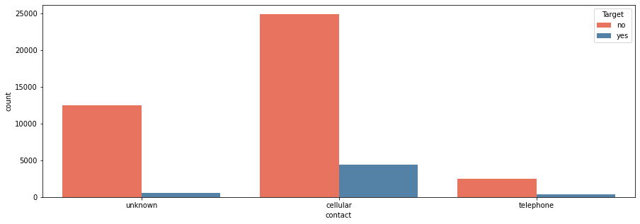

| Target contact | no | yes | All |
| --- | --- | --- | --- |
| cellular | 0.624117 | 0.826054 | 0.647741 |
| telephone | 0.063023 | 0.073738 | 0.064276 |
| unknown | 0.312860 | 0.100208 | 0.287983 |

```python
plt.figure(figsize=(15,5))
chart = sns.countplot(df['contact'], hue=df['Target'], palette=['tomato', 'steelblue'])
plt.show()

pd.crosstab(df['contact'], df['Target'], margins=True, normalize='columns')
```

**Insights:**

- Regardless of **unknown**, almost **65%** of calls were made to **cell phones**, this also accounts up to **83%** of all accepted subscribtions. This variable looks important and we should keep it.

```python
pd.crosstab(df['contact'], df['Target'], margins=True, normalize='columns').sort_values(by='yes', ascending=False)
```

| Target contact | no | yes | All |
| --- | --- | --- | --- |
| cellular | 0.624117 | 0.826054 | 0.647741 |
| unknown | 0.312860 | 0.100208 | 0.287983 |
| telephone | 0.063023 | 0.073738 | 0.064276 |

**Insights:**

- Again about **82%** of all subscribtions is comming from people through **cellular**.
- **Poutcome**

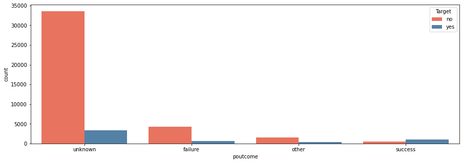

| Target poutcome | no | yes | All |
| --- | --- | --- | --- |
| failure | 0.107284 | 0.116846 | 0.108403 |
| other | 0.038400 | 0.058045 | 0.040698 |
| success | 0.013351 | 0.184912 | 0.033421 |
| unknown | 0.840965 | 0.640197 | 0.817478 |

```python
plt.figure(figsize=(15,5))
chart = sns.countplot(df['poutcome'], hue=df['Target'], palette=['tomato', 'steelblue'])
plt.show()

pd.crosstab(df['poutcome'], df['Target'], margins=True, normalize='columns')
```

**Insights:**

- **unknow** account for **84%** of all **no's** and **64%** of all **yes'es**, it has too much of an influence to be unknown. We cannot really use it for our predictions and should drop it.

```python
pd.crosstab(df['poutcome'], df['Target'], margins=True, normalize='index').sort_values(by='yes', ascending=False)
```

| Target poutcome | no | yes |
| --- | --- | --- |
| success | 0.352747 | 0.647253 |
| other | 0.833152 | 0.166848 |
| failure | 0.873903 | 0.126097 |
| All | 0.883015 | 0.116985 |
| unknown | 0.908385 | 0.091615 |

**Insights:**

- But the most conversion rate is within people who accepted subscribtion during the previous campaign.
- **Age** vs **Target**

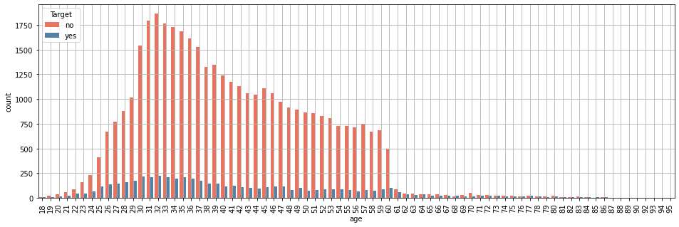

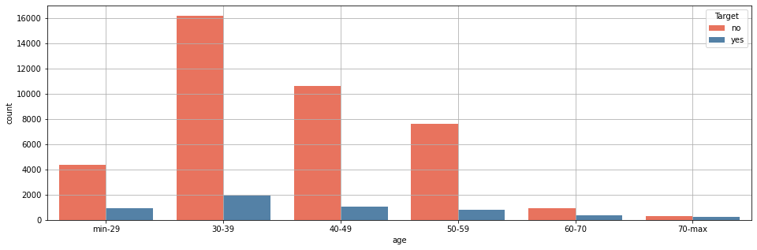

| Target age | no | yes | All |
| --- | --- | --- | --- |
| min-29 | 0.108837 | 0.175458 | 0.116631 |
| 30-39 | 0.405190 | 0.361694 | 0.400102 |
| 40-49 | 0.265317 | 0.200983 | 0.257791 |
| 50-59 | 0.190997 | 0.148421 | 0.186017 |
| 60-70 | 0.022920 | 0.072225 | 0.028688 |
| 70-max | 0.006738 | 0.041218 | 0.010772 |

| Target age | no | yes |
| --- | --- | --- |
| min-29 | 0.824009 | 0.175991 |
| 30-39 | 0.894245 | 0.105755 |
| 40-49 | 0.908795 | 0.091205 |
| 50-59 | 0.906659 | 0.093341 |
| 60-70 | 0.705474 | 0.294526 |
| 70-max | 0.552361 | 0.447639 |
| All | 0.883015 | 0.116985 |

```python
plt.figure(figsize=(16,5))
chart = sns.countplot(df['age'], hue=df['Target'], palette=['tomato', 'steelblue'])
chart.set_xticklabels(chart.get_xticklabels(), rotation=90)
plt.grid(True)
plt.show()

age_cat = pd.cut(
    df['age'],
    bins=[df['age'].min(), 29, 39, 49, 59, 70, df['age'].max()],
    labels=['min-29', '30-39', '40-49', '50-59', '60-70', '70-max'],
    include_lowest=True)

plt.figure(figsize=(16,5))
sns.countplot(age_cat, hue=df['Target'], palette=['tomato', 'steelblue'])
plt.grid(True)
plt.show()

from IPython.core.display import display
display(pd.crosstab(age_cat, df['Target'], margins=True, normalize='columns'))
display(pd.crosstab(age_cat, df['Target'], margins=True, normalize='index'))
```

**Insights:**

- Almost **36%** of all **yes'es** belongs to the age group **30-39** years, with **40-49** group comming in 2nd at ~**20%**.
- However looking into each category separetly, **70 and above** are most likely to subscribe.
- **Month**

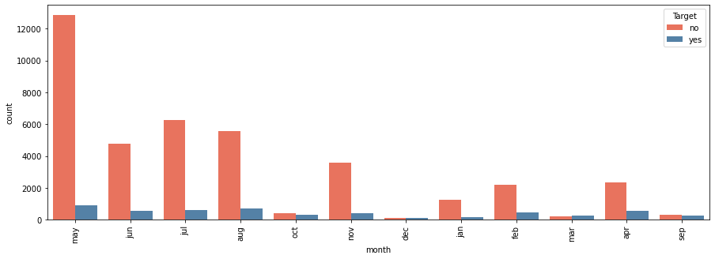

| Target month | no | yes | All |
| --- | --- | --- | --- |
| may | 0.321652 | 0.174891 | 0.304483 |
| aug | 0.139247 | 0.130081 | 0.138174 |
| jul | 0.157006 | 0.118548 | 0.152507 |
| apr | 0.058990 | 0.109094 | 0.064851 |
| jun | 0.120109 | 0.103233 | 0.118135 |
| feb | 0.055308 | 0.083381 | 0.058592 |
| nov | 0.089349 | 0.076196 | 0.087810 |
| oct | 0.010395 | 0.061070 | 0.016323 |
| sep | 0.007765 | 0.050860 | 0.012807 |
| mar | 0.005736 | 0.046890 | 0.010551 |
| jan | 0.031587 | 0.026848 | 0.031032 |
| dec | 0.002856 | 0.018907 | 0.004733 |

```python
plt.figure(figsize=(15,5))
chart = sns.countplot(df['month'], hue=df['Target'], palette=['tomato', 'steelblue'])
chart.set_xticklabels(chart.get_xticklabels(), rotation=90)
plt.show()
pd.crosstab(df['month'], df['Target'], margins=True, normalize='columns').sort_values(by='yes', ascending=False)
```

**Insights:**

```python
pd.crosstab(df['month'], df['Target'], normalize='index').sort_values(by='yes', ascending=False)
```

| Target month | no | yes |
| --- | --- | --- |
| mar | 0.480084 | 0.519916 |
| dec | 0.532710 | 0.467290 |
| sep | 0.535406 | 0.464594 |
| oct | 0.562331 | 0.437669 |
| apr | 0.803206 | 0.196794 |
| feb | 0.833522 | 0.166478 |
| aug | 0.889867 | 0.110133 |
| jun | 0.897772 | 0.102228 |
| nov | 0.898489 | 0.101511 |
| jan | 0.898788 | 0.101212 |
| jul | 0.909065 | 0.090935 |
| may | 0.932805 | 0.067195 |

**Insights:**

- This perspective is much more interesting in terms of the outcome prediction, and we can see that in **March, September, October and December** there is approx. **44-52%** chance of subscribing client to a term deposit.
- **Day**

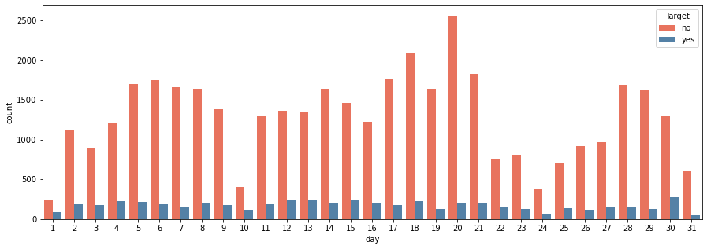

```python
plt.figure(figsize=(15,5))
chart = sns.countplot(df['day'], hue=df['Target'], palette=['tomato', 'steelblue'])
plt.show()
```

**Insights:**

- Subscribtion acceptance rate is low almost on any day, which is most likely has to do with dataset disbalance.
- **Balance**

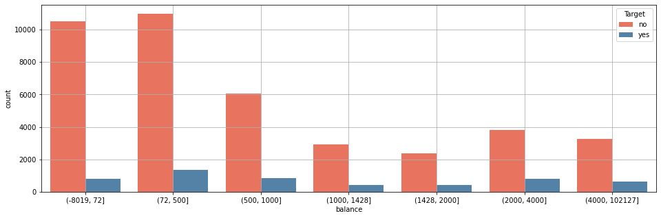

| Target balance | no | yes | All |
| --- | --- | --- | --- |
| (-8019, 72] | 0.262944 | 0.154850 | 0.250299 |
| (72, 500] | 0.275168 | 0.257705 | 0.273125 |
| (500, 1000] | 0.151700 | 0.162413 | 0.152953 |
| (1000, 1428] | 0.072919 | 0.079977 | 0.073745 |
| (1428, 2000] | 0.059618 | 0.078654 | 0.061845 |
| (2000, 4000] | 0.095489 | 0.149556 | 0.101814 |
| (4000, 102127] | 0.082162 | 0.116846 | 0.086220 |

```python
# As we discovered befor 50% of the clients has balances [72, 1428], let's use it in binning
balance_cat = pd.cut(df['balance'], bins=[df['balance'].min(), 72, 500, 1000, 1428, 2000, 4000, df['balance'].max()])

plt.figure(figsize=(16,5))
sns.countplot(balance_cat, hue=df['Target'], palette=['tomato', 'steelblue'])
plt.grid(True)
plt.show()


display(pd.crosstab(balance_cat, df['Target'], margins=True, normalize='columns'))
```

**Insights:**

- If we bin the **balace** we can see more clearly the distribution of the subscribtions vs balances. As we can see more than **25%** of subscribtions are comming from the clients with balances **[72;500]**.

### Numerical Variables

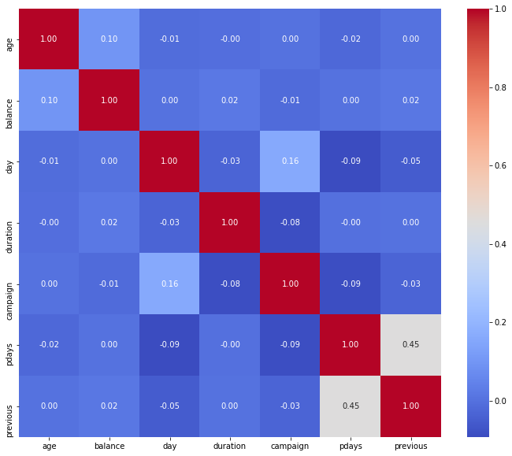

```python
plt.figure(figsize=(12,10))
sns.heatmap(df.corr(), annot = True, cmap='coolwarm', fmt='0.2f', cbar = True)
plt.show()
```

**Insights:**

- The only noticable correlation is between **pdays** and **previous**.

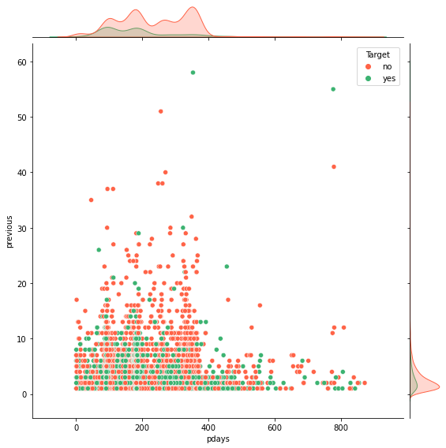

```python
# Remove outlier & concentrate on the clients who were contacted
clean_df = df[df['previous'] != 275]
only_contacted_clients = clean_df[clean_df['pdays'] != -1]

sns.jointplot(x='pdays', y='previous', hue='Target', data=only_contacted_clients, height=8, ratio=10, palette=['tomato', 'mediumseagreen']);
plt.show()
```

**Insights:**

- No visible correletion between **pdays** and **previous**.

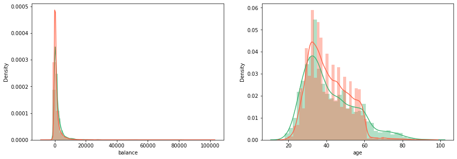

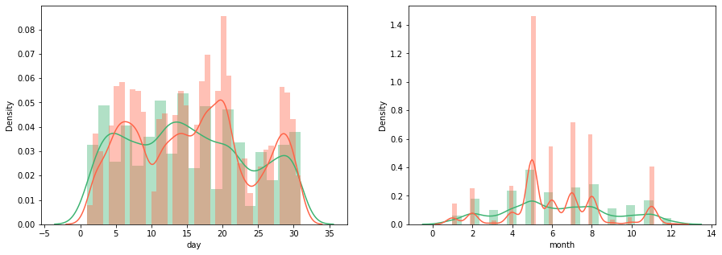

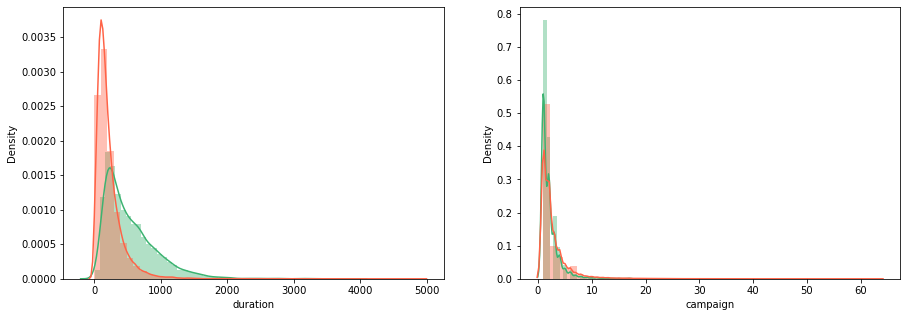

```python
cleaned_df = df.copy()
cleaned_df['month'] = pd.Categorical(
    cleaned_df['month'].replace(
        ['jan', 'feb', 'mar', 'apr', 'may', 'jun', 'jul', 'aug', 'sep', 'oct', 'nov', 'dec'],
        [1, 2, 3, 4, 5, 6, 7, 8, 9, 10, 11, 12]
    ))


for colset in [['balance', 'age'], ['day', 'month'], ['duration', 'campaign']]:
    plt.figure(figsize=(15,5))

    plt.subplot(1, 2, 1)
    sns.distplot(cleaned_df[cleaned_df['Target'] == 'yes'][colset[0]], color='mediumseagreen');
    sns.distplot(cleaned_df[cleaned_df['Target'] == 'no'][colset[0]], color='tomato');

    plt.subplot(1, 2, 2)
    sns.distplot(cleaned_df[cleaned_df['Target'] == 'yes'][colset[1]], color='mediumseagreen');
    sns.distplot(cleaned_df[cleaned_df['Target'] == 'no'][colset[1]], color='tomato');

    plt.show()
```

**Insights:**

- Again we can notice that **duration** is not a good measure for **Target** prediction. Before the call acually happaned the target is not really known.

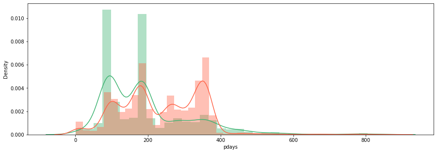

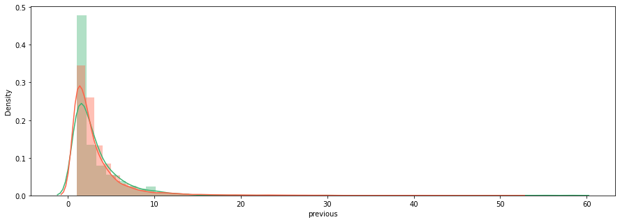

```python
clean_df = df[df['previous'] != 275]
only_contacted_clients = clean_df[clean_df['pdays'] != -1]

for col in ['pdays', 'previous']:
    plt.figure(figsize=(15,5))
    sns.distplot(only_contacted_clients[only_contacted_clients['Target'] == 'yes'][col], color='mediumseagreen');
    sns.distplot(only_contacted_clients[only_contacted_clients['Target'] == 'no'][col], color='tomato');
    plt.show()
```

**Insights:**

- There is a separate peak in **pdays** after around **300** days when subscription 'no' rate spikes.

## Getting data model ready

```python
from sklearn.preprocessing import FunctionTransformer

# Drop columns as discussed earlier.
cleaned_df = df.drop(['poutcome'], axis=1) #'duration'

# Drop outliers
size_before = cleaned_df.shape[0]
cleaned_df = cleaned_df[cleaned_df['job'] != 'unknown']
size_clean_job = cleaned_df.shape[0]
cleaned_df = cleaned_df[cleaned_df['previous'] < 275]
size_clean_prev = cleaned_df.shape[0]

print('Dropping...')
print('Initial size           :', size_before)
print('After cleaning job     : {}, dropped: {}'.format(size_clean_job, size_before - size_clean_job))
print('After cleaning previous: {}, dropped: {}'.format(size_clean_prev, size_clean_job - size_clean_prev))
print()

# Convert to categorical variable as needed

# month
cleaned_df['month'] = pd.Categorical(
    cleaned_df['month'].replace(
        ['jan', 'feb', 'mar', 'apr', 'may', 'jun', 'jul', 'aug', 'sep', 'oct', 'nov', 'dec'],
        [0, 1, 2, 3, 4, 5, 6, 7, 8, 9, 10, 11]
    ))


# education
cleaned_df['education'] = pd.Categorical(
    cleaned_df['education'].replace(
        ['primary', 'secondary', 'tertiary', 'unknown'],
        [0, 1, 2, 3]
    ))

# Convert categorical vriables to dummy variables
oneHotCols = ['default', 'housing', 'loan', 'contact', 'job', 'marital', 'Target']
cleaned_df = pd.get_dummies(cleaned_df, columns=oneHotCols, drop_first=True)

# log transform
log_transformer = FunctionTransformer(np.log1p)
cleaned_df['age'] = log_transformer.fit_transform(cleaned_df[['age']])

cleaned_df.rename(columns = {'Target_yes': 'Target'}, inplace = True)

# Define X and Y variables
X = cleaned_df.drop('Target', axis=1)
Y = cleaned_df['Target']
X.info()
```

```
Dropping...
Initial size           : 45211
After cleaning job     : 44923, dropped: 288
After cleaning previous: 44922, dropped: 1

<class 'pandas.core.frame.DataFrame'>
Int64Index: 44922 entries, 0 to 45210
Data columns (total 26 columns):
 #   Column             Non-Null Count  Dtype
---  ------             --------------  -----
 0   age                44922 non-null  float64
 1   education          44922 non-null  category
 2   balance            44922 non-null  int64
 3   day                44922 non-null  int64
 4   month              44922 non-null  category
 5   duration           44922 non-null  int64
 6   campaign           44922 non-null  int64
 7   pdays              44922 non-null  int64
 8   previous           44922 non-null  int64
 9   default_yes        44922 non-null  uint8
 10  housing_yes        44922 non-null  uint8
 11  loan_yes           44922 non-null  uint8
 12  contact_telephone  44922 non-null  uint8
 13  contact_unknown    44922 non-null  uint8
 14  job_blue-collar    44922 non-null  uint8
 15  job_entrepreneur   44922 non-null  uint8
 16  job_housemaid      44922 non-null  uint8
 17  job_management     44922 non-null  uint8
 18  job_retired        44922 non-null  uint8
 19  job_self-employed  44922 non-null  uint8
 20  job_services       44922 non-null  uint8
 21  job_student        44922 non-null  uint8
 22  job_technician     44922 non-null  uint8
 23  job_unemployed     44922 non-null  uint8
 24  marital_married    44922 non-null  uint8
 25  marital_single     44922 non-null  uint8
dtypes: category(2), float64(1), int64(6), uint8(17)
memory usage: 3.6 MB
```

## Split Data

Split the data into training and test set in the ratio of 70:30 respectively.

```python
from sklearn.model_selection import train_test_split

X_train, X_test, y_train, y_test = train_test_split(X, Y, test_size=0.30, random_state=33)
```

```python
def get_percentage(df, subset):
    return len(subset)/len(df.index) * 100

print('{0:0.2f}% data is in training set'.format(get_percentage(cleaned_df, X_train)))
print('{0:0.2f}% data is in test set'.format(get_percentage(cleaned_df, X_test)))
```

```
70.00% data is in training set
30.00% data is in test set
```

Now let's check **Target** ratio in split data

```python
def get_count_percentage_df(df, col, value):
    matching_count = len(df[df[col] == value])
    percentage_of_total = (matching_count/len(df.index)) * 100
    return [matching_count, percentage_of_total]

def get_count_percentage_s(s, value):
    matching_count = len(s[s == value])
    percentage_of_total = (matching_count/len(s)) * 100
    return [matching_count, percentage_of_total]

count, percentage = get_count_percentage_df(cleaned_df, 'Target', 1)
print("Original - Personal Loan 1 : {0} ({1:0.2f}%)".format(count, percentage))
count, percentage = get_count_percentage_df(cleaned_df, 'Target', 0)
print("Original - Personal Loan 0 : {0} ({1:0.2f}%)".format(count, percentage))
print()
count, percentage = get_count_percentage_s(y_train, 1)
print("Training - Personal Loan 1 : {0} ({1:0.2f}%)".format(count, percentage))
count, percentage = get_count_percentage_s(y_train, 0)
print("Training - Personal Loan 0 : {0} ({1:0.2f}%)".format(count, percentage))
print()
count, percentage = get_count_percentage_s(y_test, 1)
print("Test     - Personal Loan 1 : {0} ({1:0.2f}%)".format(count, percentage))
count, percentage = get_count_percentage_s(y_test, 0)
print("Test     - Personal Loan 0 : {0} ({1:0.2f}%)".format(count, percentage))
```

```
Original - Personal Loan 1 : 5255 (11.70%)
Original - Personal Loan 0 : 39667 (88.30%)

Training - Personal Loan 1 : 3655 (11.62%)
Training - Personal Loan 0 : 27790 (88.38%)

Test     - Personal Loan 1 : 1600 (11.87%)
Test     - Personal Loan 0 : 11877 (88.13%)
```

**Insights:**

- Testing & Training data has **Target** split close to the original dataset, good split.

### Define Utility Functions

```python
from sklearn.metrics import roc_auc_score, roc_curve

def report_ROC(estimator, x_te, y_te, roc_auc, title, force_show=True):
    #plt.figure()
    fpr, tpr, thresholds = roc_curve(y_te, estimator.predict_proba(x_te)[:,1])
    plt.plot(fpr, tpr, label='{} (area = {:0.2f})'.format(title, roc_auc))
    plt.plot([0, 1], [0, 1],'r--')
    plt.xlim([0.0, 1.0])
    plt.ylim([0.0, 1.05])
    plt.xlabel('False Positive Rate')
    plt.ylabel('True Positive Rate')
    plt.title('Receiver operating characteristic')
    plt.legend(loc="lower right")
    if(force_show):
        plt.show()

    return {'fpr': fpr, 'tpr':tpr, 'thresholds': thresholds, 'roc_auc': roc_auc}
```

```python
from sklearn.metrics import confusion_matrix

def cm_report(cm, title, report, force_show=True):
    flat_cm = cm.flatten();
    group_names = ['TN', 'FP', 'FN', 'TP']
    group_counts = ['{}'.format(value) for value in flat_cm]
    labels = [f'{v1}\n{v2}' for v1, v2 in zip(group_names, group_counts)]
    labels = np.asarray(labels).reshape(2,2)
    color_map = { flat_cm[0]:'mediumseagreen', flat_cm[1]:'tomato', flat_cm[2]:'tomato', flat_cm[3]:'mediumseagreen'}
    colors =  [(color_map[index] if index in color_map.keys() else 'black') for index in np.arange(flat_cm.min(), flat_cm.max() + 1)]

    #plt.figure(figsize = (7,5))
    sns.heatmap(cm, annot=labels, fmt='', xticklabels = [0, 1], yticklabels = [0, 1], cmap=colors, cbar = False, annot_kws={"size": 20})
    plt.ylabel('Actual')
    plt.xlabel('Predicted')
    if(force_show):
        plt.show()

    TP = cm.flatten()[3]
    TN = cm.flatten()[0]
    FP = cm.flatten()[1]
    FN = cm.flatten()[2]

    recall = TP/(TP + FN)
    specificity = TN/(FP + TN)
    precision = TP/(TP + FP)
    accuracy = (TP + TN)/(TP + TN + FP + FN)
    error_rate = 1 - accuracy

    report['Accuracy-testing'] = accuracy
    report['Precision'] = precision
    report['Recall/Sensitivity/TPR'] = recall
    report['Specificity/TNR'] = specificity
    report['Error Rate'] = error_rate
    report['TP'] = TP
    report['TN'] = TN
    report['FP'] = FP
    report['FN'] = FN

    return report
```

```python
from sklearn.metrics import recall_score, precision_score, f1_score, accuracy_score, classification_report

def estimator_report(estimator, title, x_tr, y_tr, x_te, y_te):
    y_pred = estimator.predict(x_te)

    # Other ways
    # print('Training Accuracy      : ', estimator.score(x_tr, y_tr))
    # print('Testing  Accuracy      : ', estimator.score(x_te, y_te))
    # accuracy_score(y_test, y_predict)
    # classification_report(y_test, y_predict)
    # print('Recall          :', recall_score(y_test, y_predict))
    # print('Precision       :', precision_score(y_test, y_predict))
    # print('F1 Score        :', f1_score(y_test, y_predict))
    # print('Roc Auc Score   :', roc_auc_score(y_test, y_predict))

    accuracy_training = estimator.score(x_tr, y_tr)
    f1 = f1_score(y_te, y_pred)
    cm = confusion_matrix(y_te, y_pred)
    roc_auc = roc_auc_score(y_te, estimator.predict(x_te))

    estimator_cm_report = pd.DataFrame(
        [[accuracy_training, -1, -1, -1, -1, roc_auc, f1, -1, -1, -1, -1, -1]],
        columns=['Accuracy-training', 'Accuracy-testing', 'Precision', 'Recall/Sensitivity/TPR', 'Specificity/TNR', 'ROC AUC', 'F1', 'Error Rate', 'TP', 'TN', 'FP', 'FN'],
        index=[title]
    )

    # Confusion matrix & ROC AUC
    plt.figure(figsize=(15,5))

    plt.subplot(1, 2, 1)
    estimator_cm_report = cm_report(cm, title, estimator_cm_report, False)

    plt.subplot(1, 2, 2)
    roc_report = report_ROC(estimator, x_te, y_te, roc_auc, title, force_show=False)

    plt.show()


    # Feature Importance
    coeff = []
    if hasattr(estimator, 'feature_importances_'):
        coeff = estimator.feature_importances_
    elif hasattr(estimator, 'coef_'):
        coeff = abs(estimator.coef_[0])

    if len(coeff) > 0:
        fi_df = pd.DataFrame(coeff, columns = ['Importance'], index = x_tr.columns).sort_values(by='Importance', ascending=False).reset_index()
        fi_df.rename(columns = {'index': 'Feature'}, inplace=True)
        display(fi_df.head(5))

        chart = sns.barplot(x='Feature', y='Importance', data=fi_df, palette='Reds_r')
        chart.set_xticklabels(chart.get_xticklabels(),  rotation=90)
        chart.set(title='Feature Importance',  xlabel='', ylabel='')
        plt.show()

    return {'cm': estimator_cm_report, 'roc': roc_report, 'fi':fi_df if len(coeff) > 0 else None , 'title': title}
```

```python
def draw_combined_ROC(reports):
    line_colors = ['r', 'g', 'b', 'm', 'darkorange', 'dimgray', 'c', 'black', 'black']

    plt.figure(figsize=(10,10))
    for index, report in enumerate(reports):
        fpr = report['roc']['fpr']
        tpr = report['roc']['tpr']
        roc_auc = report['roc']['roc_auc']
        title = report['title']
        plt.plot(fpr, tpr, label='{} (area = {:0.2f})'.format(title, roc_auc), color=line_colors[index])

    plt.plot([0, 1], [0, 1],'r--')
    plt.xlim([0.0, 1.0])
    plt.ylim([0.0, 1.0])
    plt.xlabel('False Positive Rate')
    plt.ylabel('True Positive Rate')
    plt.title('Receiver operating characteristic')
    plt.legend(loc="lower right")
    plt.show()
```

# 3. Classifiers

## Logistic Regression

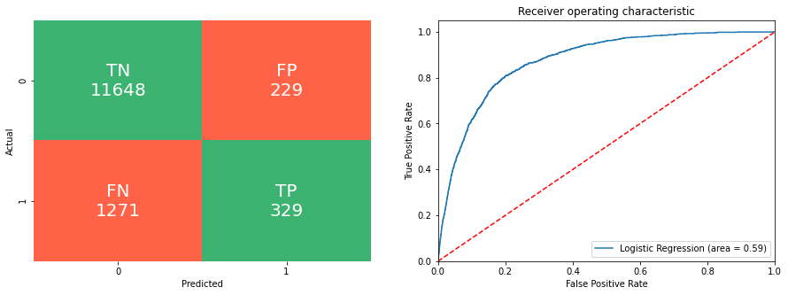

|  | Feature | Importance |
| --- | --- | --- |
| 0 | contact_unknown | 1.126454 |
| 1 | housing_yes | 0.949169 |
| 2 | loan_yes | 0.621690 |
| 3 | job_student | 0.602310 |
| 4 | job_retired | 0.545663 |

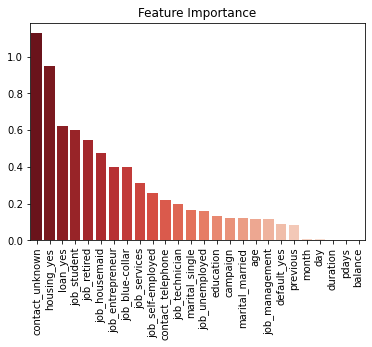

|  | Accuracy-training | Accuracy-testing | Precision | Recall/Sensitivity/TPR | Specificity/TNR | ROC AUC | F1 | Error Rate | TP | TN | FP | FN |
| --- | --- | --- | --- | --- | --- | --- | --- | --- | --- | --- | --- | --- |
| Logistic Regression | 0.891557 | 0.888699 | 0.589606 | 0.205625 | 0.980719 | 0.593172 | 0.304912 | 0.111301 | 329 | 11648 | 229 | 1271 |

```python
from sklearn.linear_model import LogisticRegression

logreg = LogisticRegression(solver='newton-cg', random_state=55)
logreg.fit(X_train, y_train)

lr_report = estimator_report(logreg, 'Logistic Regression', X_train, y_train, X_test, y_test)
display(lr_report['cm'])
```

**Insights:**

## Decison Tree (CART)

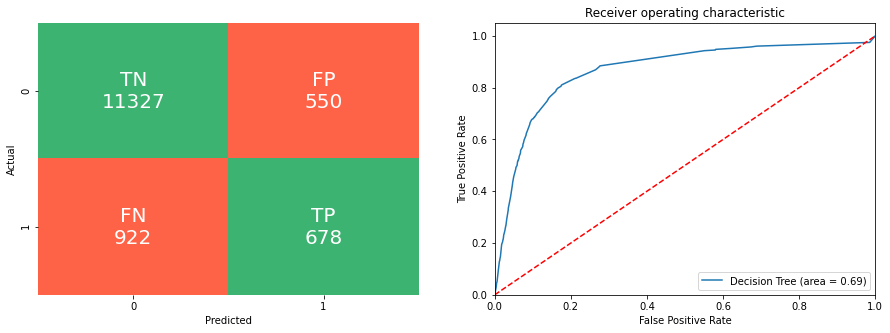

|  | Feature | Importance |
| --- | --- | --- |
| 0 | duration | 0.497817 |
| 1 | pdays | 0.127003 |
| 2 | housing_yes | 0.101872 |
| 3 | month | 0.091487 |
| 4 | age | 0.057272 |

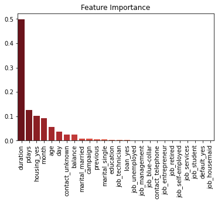

|  | Accuracy-training | Accuracy-testing | Precision | Recall/Sensitivity/TPR | Specificity/TNR | ROC AUC | F1 | Error Rate | TP | TN | FP | FN |
| --- | --- | --- | --- | --- | --- | --- | --- | --- | --- | --- | --- | --- |
| Decision Tree | 0.911782 | 0.890777 | 0.552117 | 0.42375 | 0.953692 | 0.688721 | 0.479491 | 0.109223 | 678 | 11327 | 550 | 922 |

```python
from sklearn.tree import DecisionTreeClassifier

dTree = DecisionTreeClassifier(criterion = 'gini', max_depth=8, random_state=55, min_samples_leaf=5) #  min_impurity_decrease=0.01
dTree.fit(X_train, y_train)

dt_report = estimator_report(dTree, 'Decision Tree', X_train, y_train, X_test, y_test)
display(dt_report['cm'])
```

## Ensemble - Bagging

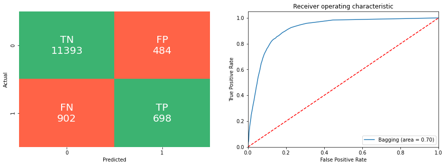

|  | Accuracy-training | Accuracy-testing | Precision | Recall/Sensitivity/TPR | Specificity/TNR | ROC AUC | F1 | Error Rate | TP | TN | FP | FN |
| --- | --- | --- | --- | --- | --- | --- | --- | --- | --- | --- | --- | --- |
| Bagging | 0.995389 | 0.897158 | 0.590525 | 0.43625 | 0.959249 | 0.697749 | 0.501797 | 0.102842 | 698 | 11393 | 484 | 902 |

```python
from sklearn.ensemble import BaggingClassifier

bgcl = BaggingClassifier(n_estimators=68, max_samples=0.7, random_state=55)
bgcl = bgcl.fit(X_train, y_train)

b_report = estimator_report(bgcl, 'Bagging', X_train, y_train, X_test, y_test)
display(b_report['cm'])
```

## Ensemble - AdaBoosting

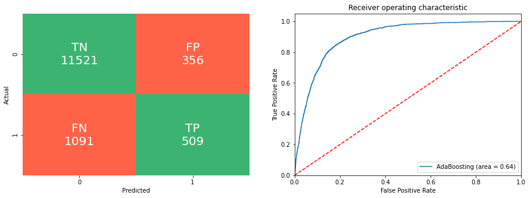

|  | Feature | Importance |
| --- | --- | --- |
| 0 | month | 0.295775 |
| 1 | duration | 0.197183 |
| 2 | pdays | 0.169014 |
| 3 | age | 0.056338 |
| 4 | balance | 0.056338 |

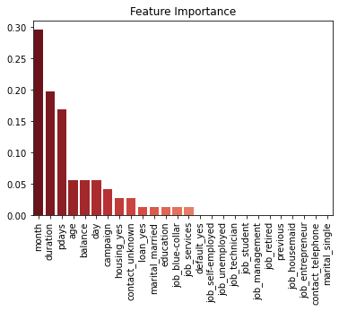

|  | Accuracy-training | Accuracy-testing | Precision | Recall/Sensitivity/TPR | Specificity/TNR | ROC AUC | F1 | Error Rate | TP | TN | FP | FN |
| --- | --- | --- | --- | --- | --- | --- | --- | --- | --- | --- | --- | --- |
| AdaBoosting | 0.895277 | 0.892632 | 0.588439 | 0.318125 | 0.970026 | 0.644076 | 0.412982 | 0.107368 | 509 | 11521 | 356 | 1091 |

```python
from sklearn.ensemble import AdaBoostClassifier

abcl = AdaBoostClassifier(n_estimators=71, algorithm='SAMME.R', random_state=55)
abcl = abcl.fit(X_train, y_train)

ab_report = estimator_report(abcl, 'AdaBoosting', X_train, y_train, X_test, y_test)
display(ab_report['cm'])
```

## Ensemble - GradientBoost

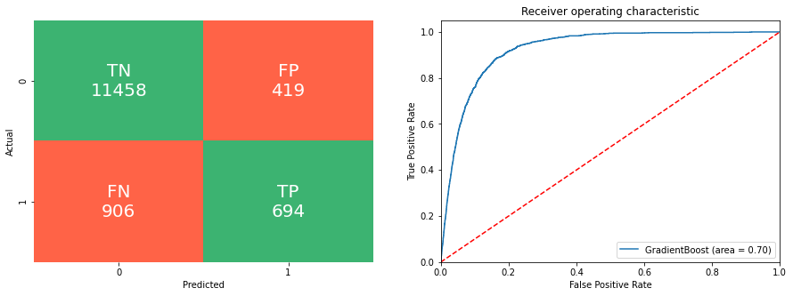

|  | Feature | Importance |
| --- | --- | --- |
| 0 | duration | 0.450566 |
| 1 | month | 0.123332 |
| 2 | pdays | 0.098910 |
| 3 | age | 0.063689 |
| 4 | housing_yes | 0.060555 |

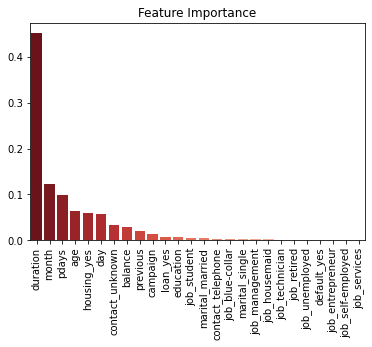

|  | Accuracy-training | Accuracy-testing | Precision | Recall/Sensitivity/TPR | Specificity/TNR | ROC AUC | F1 | Error Rate | TP | TN | FP | FN |
| --- | --- | --- | --- | --- | --- | --- | --- | --- | --- | --- | --- | --- |
| GradientBoost | 0.926984 | 0.901684 | 0.62354 | 0.43375 | 0.964722 | 0.699236 | 0.511611 | 0.098316 | 694 | 11458 | 419 | 906 |

```python
from sklearn.ensemble import GradientBoostingClassifier

gbcl = GradientBoostingClassifier(n_estimators=66, criterion='friedman_mse', max_depth=6, max_features=8, random_state=55)
gbcl = gbcl.fit(X_train, y_train)

gb_report = estimator_report(gbcl, 'GradientBoost', X_train, y_train, X_test, y_test)
display(gb_report['cm'])
```

## Ensemble - RandomForest Classifier

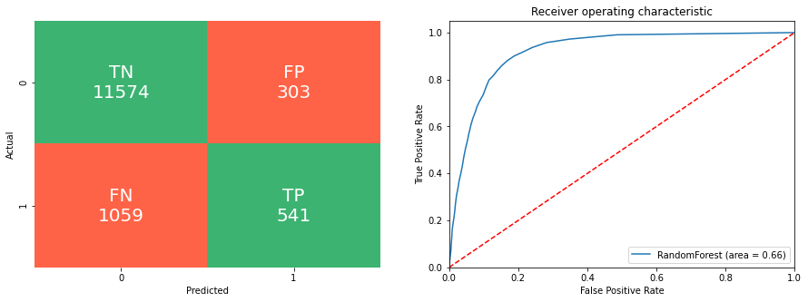

|  | Feature | Importance |
| --- | --- | --- |
| 0 | duration | 0.383983 |
| 1 | month | 0.090782 |
| 2 | balance | 0.080486 |
| 3 | day | 0.075220 |
| 4 | age | 0.074607 |

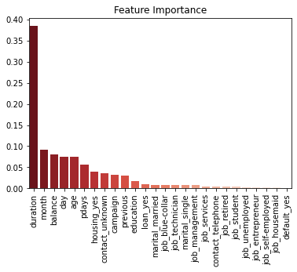

|  | Accuracy-training | Accuracy-testing | Precision | Recall/Sensitivity/TPR | Specificity/TNR | ROC AUC | F1 | Error Rate | TP | TN | FP | FN |
| --- | --- | --- | --- | --- | --- | --- | --- | --- | --- | --- | --- | --- |
| RandomForest | 0.993862 | 0.898939 | 0.640995 | 0.338125 | 0.974489 | 0.656307 | 0.442717 | 0.101061 | 541 | 11574 | 303 | 1059 |

```python
from sklearn.ensemble import RandomForestClassifier

rfcl = RandomForestClassifier(n_estimators=50, criterion='gini', max_features=8, max_samples=0.7, class_weight='balanced_subsample', random_state=55)
rfcl = rfcl.fit(X_train, y_train)

rf_report = estimator_report(rfcl, 'RandomForest', X_train, y_train, X_test, y_test)
display(rf_report['cm'])
```

## Ensemble - XGBClassifier

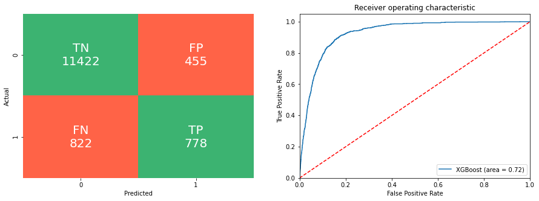

|  | Feature | Importance |
| --- | --- | --- |
| 0 | contact_unknown | 0.132911 |
| 1 | housing_yes | 0.120832 |
| 2 | duration | 0.093104 |
| 3 | previous | 0.067522 |
| 4 | month | 0.060739 |

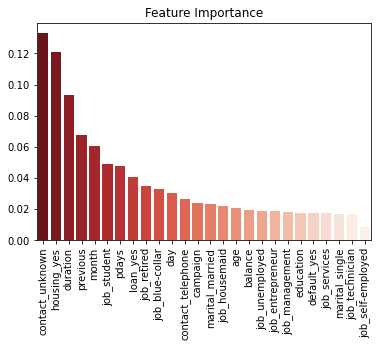

|  | Accuracy-training | Accuracy-testing | Precision | Recall/Sensitivity/TPR | Specificity/TNR | ROC AUC | F1 | Error Rate | TP | TN | FP | FN |
| --- | --- | --- | --- | --- | --- | --- | --- | --- | --- | --- | --- | --- |
| XGBoost | 0.952266 | 0.905246 | 0.630981 | 0.48625 | 0.961691 | 0.72397 | 0.549241 | 0.094754 | 778 | 11422 | 455 | 822 |

```python
from xgboost.sklearn import XGBClassifier

XN = X.copy()
XN['age'] = XN['age'].astype('int64')
XN['education'] = XN['education'].astype('int64')
XN['month'] = XN['month'].astype('int64')
X_train, X_test, y_train, y_test = train_test_split(XN, Y, test_size=0.30, random_state=33)

xgbc = XGBClassifier(n_estimators=110, colsample_bytree=0.8, min_child_weight=2, random_state=55)
xgbc = xgbc.fit(X_train, y_train)

xgb_report = estimator_report(xgbc, 'XGBoost', X_train, y_train, X_test, y_test)
display(xgb_report['cm'])
```

# 4. Comparison

```python
reports = [lr_report, dt_report, b_report, ab_report, gb_report, rf_report, xgb_report];

report_cm_df = pd.concat(map(lambda r: r['cm'], reports), sort=False)
display(report_cm_df)
```

|  | Accuracy-training | Accuracy-testing | Precision | Recall/Sensitivity/TPR | Specificity/TNR | ROC AUC | F1 | Error Rate | TP | TN | FP | FN |
| --- | --- | --- | --- | --- | --- | --- | --- | --- | --- | --- | --- | --- |
| Logistic Regression | 0.891557 | 0.888699 | 0.589606 | 0.205625 | 0.980719 | 0.593172 | 0.304912 | 0.111301 | 329 | 11648 | 229 | 1271 |
| Decision Tree | 0.911782 | 0.890777 | 0.552117 | 0.423750 | 0.953692 | 0.688721 | 0.479491 | 0.109223 | 678 | 11327 | 550 | 922 |
| Bagging | 0.995389 | 0.897158 | 0.590525 | 0.436250 | 0.959249 | 0.697749 | 0.501797 | 0.102842 | 698 | 11393 | 484 | 902 |
| AdaBoosting | 0.895277 | 0.892632 | 0.588439 | 0.318125 | 0.970026 | 0.644076 | 0.412982 | 0.107368 | 509 | 11521 | 356 | 1091 |
| GradientBoost | 0.926984 | 0.901684 | 0.623540 | 0.433750 | 0.964722 | 0.699236 | 0.511611 | 0.098316 | 694 | 11458 | 419 | 906 |
| RandomForest | 0.993862 | 0.898939 | 0.640995 | 0.338125 | 0.974489 | 0.656307 | 0.442717 | 0.101061 | 541 | 11574 | 303 | 1059 |
| XGBoost | 0.952266 | 0.905246 | 0.630981 | 0.486250 | 0.961691 | 0.723970 | 0.549241 | 0.094754 | 778 | 11422 | 455 | 822 |

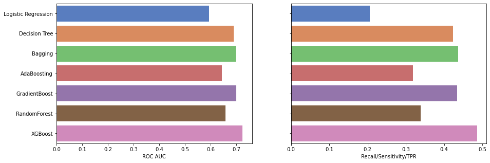

```python
ddf = report_cm_df.reset_index().rename(columns={'index':'Classifier'})

plt.figure(figsize=(15,5))

plt.subplot(1, 2, 1)
chart = sns.barplot(ddf['ROC AUC'], ddf['Classifier'], palette='muted')
chart.set(ylabel='')

plt.subplot(1, 2, 2)
chart = sns.barplot(ddf['Recall/Sensitivity/TPR'], ddf['Classifier'], palette='muted')
chart.set(yticklabels=[], ylabel='')

plt.show()
```

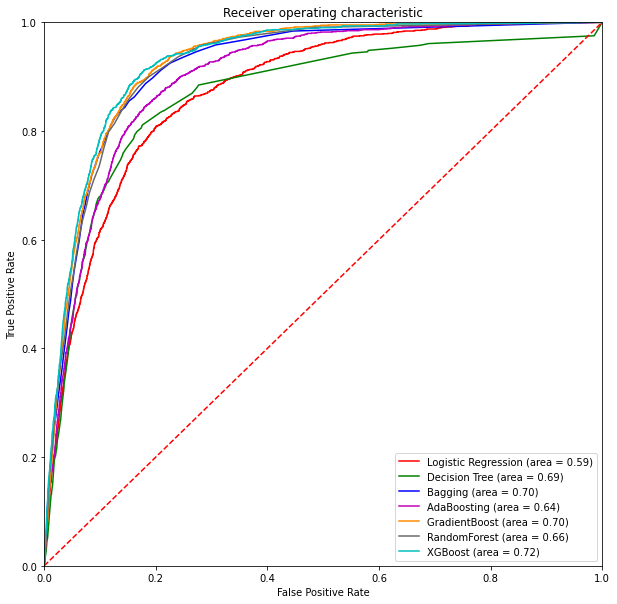

```python
draw_combined_ROC(reports)
```

**Insights:**

- After tuning hyper parameters & trying out different classifiers, **XGBoost** gave us the best **Recall** and **ROC AUC Score** which are important for out prediction of succesful subscribtions.
- **Logistic Regression** came last at **Recall** & **ROC AUC Score**.
- Interestingly simple Decision Tree performed almost the same to Bagging or Boosting.

# 5. Conclusions

- **XGBClassifier** gave us the **best results**, so let's discuss it below.
- **Model comments**
1. Interestingly: Clients who had been contacted during last campaign have additional data expressed in columns: **poutcome, previous and pdays**. If we think about it we could have a separate model for this subset of clients, or somehow let an overall model know how to split the data.
2. **Duration** highly affects the output **Target**, if duration = 0 then Traget = 'no'. Yet, the duration is not known before a call is performed. Also, after the end of the call Traget is obviously known. Because our task is to predict future outcome we could discard this variable to get a more realistic predictive model.
- **Model outcomes**
- It is important to mention that there is some disbalance in the initial dataset, we have only **11.7%** cases of people who subscribed a term deposit, and therefore **88.3%** of people who did not.
- Consequently, in our model we got very good at detecting people who won't accept subscribe a term deposit (**Specificity - 0.96**).
- Dispite the disbalance, we still managed to achive **Max Recall of ~0.49**, which is not completely bad. If we want to get better at predicting potential subscribers we want more data on succesful aceptance.
- **F1 score** gives us hormonic mean for **TPR & FPR** and shows us how good we did at predicting people who subscribes a term deposit, ~**0.55** out of 1.
- **Important Features**

The top 6 of most influencial features for the model's output. Based on the feature importance values.

1. Contact
2. Housing
3. Duration
4. Previous
5. Month
6. Job

Interestingly, **Education**, **Balance** and **Age** have low importance.

Overall our model can provide value to the bank.